# Supplementary material to Rasplus *et al* 2020 - RADseq phylogenomics of *Ficus* species

# 1 Content of this document

This document provides the `R` code to perform the analyses presented in supplementary figures FigS4C (PCA analysis of GC content for sect. *Pharmacosycea* vs other fig trees - Mixtiflores excluded) and FigS5 (PCA analysis of LB scores for sect. *Pharmacosycea* vs other fig trees).

The corresponding datasets are available in example_figureS4C.csv and example_figureS5.csv respectively.

The code has been discussed by J.-P. Rossi, J.-Y. Rasplus and A. Cruaud and written by JPR.

# 2 Required `R` packages

The `R` code below requires the `R` package `ade4` (PCA) and `httr` (reading datasets from the Github).

To install `ade4` type `install.package("ade4")` in the `R` console.

Of course, you should have installed `R` before (check `R` site here: https://cran.r-project.org/)

Note that the raw data can be read as a `.csv` file using the `R` function `read.csv`. If your own data come as `.xls` files you may need the `R` package `gdata` or something equivalent.

# 3 Managing raw data

## 3.1 Reading from data file

```r
rm(list=ls())
library(httr)
# reading the file example_figureS4c.csv corresponding to Figure FigS4C
g <- GET(url="https://raw.githubusercontent.com/acruaud/radseq_ficus_2020/master/PCA/example_figureS4C.csv")
d<-read.csv(g$url, sep=",", stringsAsFactors = F)  #note that the field separator of the csv is "," in the example files and that empty cells (missing data) have been filled with "NA"
```

We check the matrix dimensions (nb columns and lines) to make sure all taxa and all loci are loaded.

```r
dim(d)
```

```
## [1]  49 585
```

There are 49 rows that stand for taxa. There are 585 columns. The 2 first columns give information on taxa labels and group of taxa. The remaining 583 columns correspond to GC content of taxa for each locus.

We can check the names of the first 5 columns:

```r
names(d)[1:5]
```

```
## [1] "class"       "taxa_labels" "loci100"     "loci101"     "loci102"
```

```r
head(d)[1:5, 1:5]
```

```
##   class                   taxa_labels loci100 loci101 loci102
## 1     1     F_insipida_JRAS06137_0001   0.460   0.469   0.363
## 2     1  F_gigantosyce_JRAS06146_0001   0.469   0.478   0.363
## 3     1 F_crassivenosa_JRAS06891_0001      NA   0.478   0.363
## 4     1    F_carchiana_JRAS06894_0001   0.469   0.478   0.363
## 5     1   F_torresiana_JRAS06908_0001   0.460   0.478   0.363
```

We can list the different classes (= groups of taxa) to make sure data have been loaded correctly:

```r
unique(d$class)
```

```
## [1] 1 2
```

Classes are groups of species. When the dataset includes more than 2 classes (=groups), unnecessary rows can be removed. Here or you may prefer to use your usual spreadsheet. In this example, Mixtiflores have been removed from the data set; fig trees belonging to sect *Pharmacosycea* are in class (=group) 1 while other fig trees are in class (=group) 2.

## 3.2 Dealing with `NA` data

Some cells of the `data.frame` might contain NA when there is no sequence for the locus (missing values).

Here we can test whether our data set contains missing data calculate the number of loci that have missing values

```r
isna.col <- apply(X=d[,-c(1,2)], MARGIN=2, FUN=function(x) any(is.na(x)))
any(isna.col==TRUE)
```

```
## [1] TRUE
```

and calculate the number of loci for which we have missing data.

```r
length(which(isna.col==TRUE))
```

```
## [1] 579
```

This is huge given that NAs are not allowed in PCA ! The first solution is to remove either the locus or the species. However, as most data sets are patchy like here, this solution will often result in the complete deletion of the `data.frame`. Thus, we decided to replace NA values by the mean value of all available observations of the corresponding locus following Dray & Josse (2015).

So, we create a function to do the job:

```r
NAtomean <- function(x) {x[which(is.na(x)==TRUE)] <- mean(x, na.rm=TRUE) ; return(x)}
```

And we use the function to create a new matrix (d) in which NAs have been replaced by the mean value of all available observations of the corresponding locus

```r
labels <- d[,c(1,2)] ; d <- d[,-c(1,2)]
groups <- factor(labels[,1])
d <- data.frame(apply(X=d, MARGIN=2, FUN=NAtomean))
```

and check the dimensions of the new matrix

```r
dim(d)
```

```
## [1]  49 583
```

# 4 Data analysis using the PCA

## 4.1 Initial (full) PCA

We first perform a first PCA using the full dataset.

```r
library(ade4)
pca <- dudi.pca(d, scannf = F, nf = 5)
```

The eigenvalues (i.e. the variance of the species scores upon the principal axes) are given by:

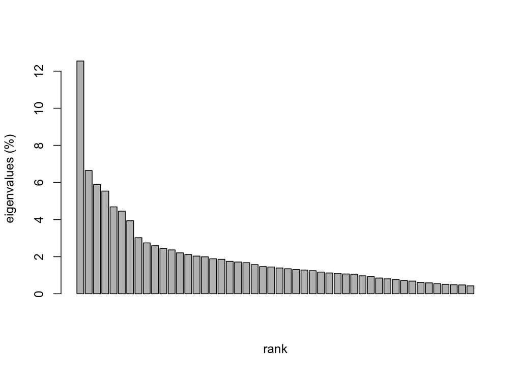

```r
barplot(height=100*pca$eig/sum(pca$eig), xlab="rank", ylab="eigenvalues (%)")
```

The species scores upon the first two axes can be represented as follows:

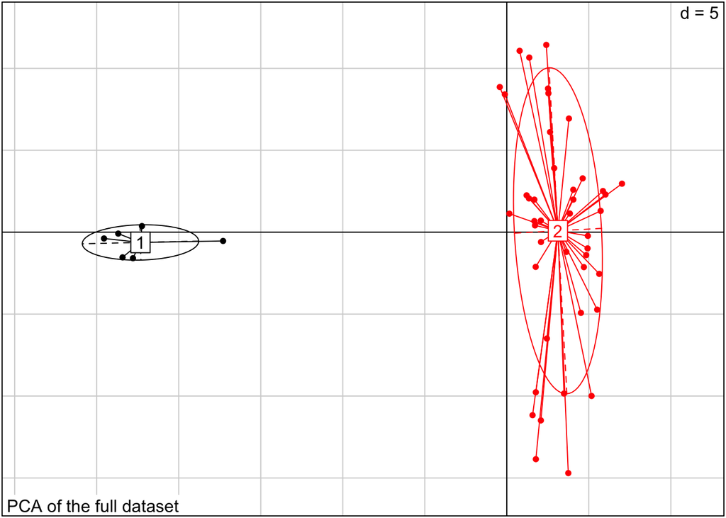

```r
s.class(dfxy=pca$li, fac=groups, col=c("black", "red"), sub="PCA of the full dataset")
```

In this plot, species belonging to sect. *Pharmacosycea* = group 1 are in black and other fig trees = group 2 are in red.

Note that you may export graphs with the `pdf` function of `R`. To export the previous graph (PCA on the complete data set) you should use something like below (uncomment the cmd to make it work - i.e remove the #). A file named `PCA_complete_dataset.pdf` will be created in your current directory.

```r
#pdf(file="PCA_complete_dataset.pdf")
#s.class(dfxy=pca$li, fac=groups, col=c("black", "red"), sub="PCA of the full dataset")
#dev.off()
```

Another way to display the same information as the previous graph is:

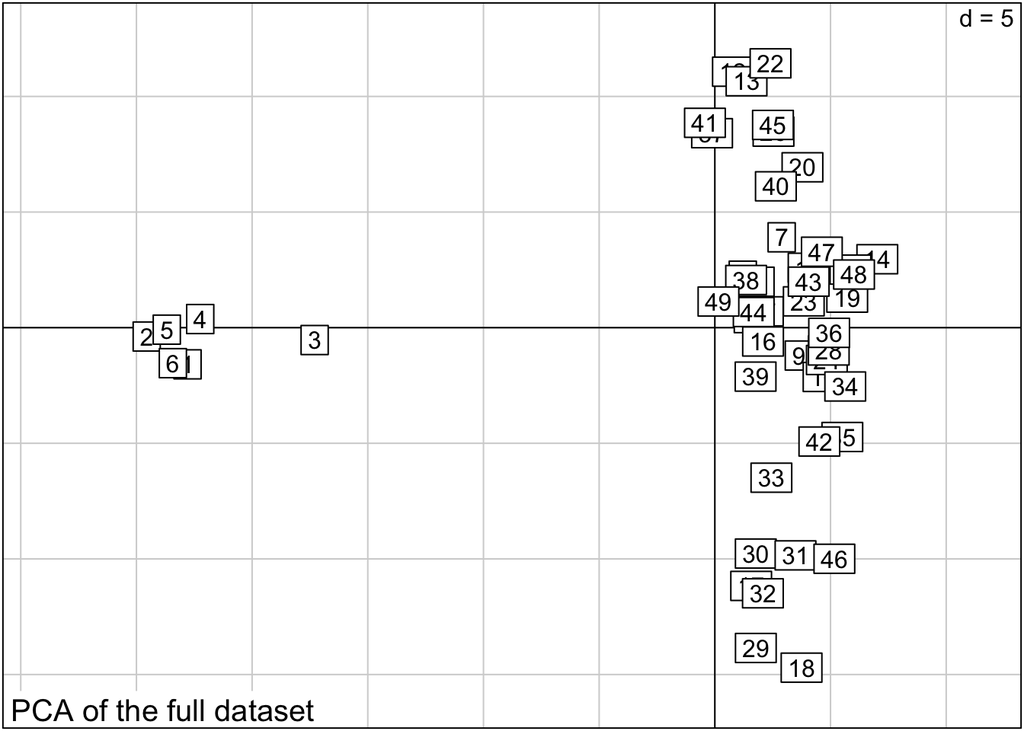

```r
s.label(dfxy=pca$li, xax = 1, yax = 2, label=row.names(d), sub="PCA of the full dataset")
```

Here, labels are numbers corresponding to species but species name could be used instead.

## 4.2 PCAs of thinned datasets

The idea is to explore how removing the loci that have the highest correlation with the first principal component (i.e. axis) decreases the distance between groups (classes) 1 and 2. This means that we need to sort the loci in function of their correlation (i.e. their score) upon the first axis of the PCA.

For that purpose we create a new `data.frame` and store the scores of the loci that are given in the object `pca$co`.

```r
genes.df <- data.frame(names(d))
genes.df[,1] <- as.character(genes.df[,1])
genes.df$score.pc1 <- pca$co[,1]
names(genes.df) <- c("loci", "pc1")
head(genes.df)
```

```
##      loci        pc1
## 1 loci100  0.1735608
## 2 loci101 -0.7538363
## 3 loci102  0.2447913
## 4 loci103  0.4239923
## 5 loci104  0.3533326
## 6 loci105  0.2158756
```

```r
genes.df.ordered <- genes.df[order(-genes.df[,2]), ]
head(genes.df.ordered)
```

```
##        loci       pc1
## 367 loci430 0.8738155
## 103 loci193 0.8003328
## 136 loci222 0.7597904
## 567  loci85 0.7459044
## 238 loci314 0.7457877
## 580  loci97 0.7416996
```

## 4.3 How many iterations?

Removing the loci will be done in an iteratuve way. Each iteration corresponds to the PCA of a thinned dataset. The first thinned dataset is the original dataset minus the locus displaying the highest correlation with the first component of the full PCA. In the second iteration, the two loci showing the highest correlation with the first components are removed. And so on.

In this example, the maximum number of iterations is fixed to 550. Note that it is better to keep enough loci in the last PCA to make the analysis meaningfull.

```r
N <- 550
```

## 4.4 PCAs on thinned datasets

The code below performes the 550 PCAs with the corresponding thinned datasets.

```r
lim <- 1 ; increm <- 1
list_pca <- vector("list", length=N+1)
list_pca[[1]] <- dudi.pca(d, scannf = F, nf = 5) # initial pca (i.e. with full dataset)

for(i in 1:(N)){
  retir <- genes.df.ordered[1:lim,1]
  m <- match(retir, names(d))
  temp <- d[,-m]
  list_pca[[i+1]] <- dudi.pca(temp, scannf = F, nf = 5)
  lim <- lim+increm
  }
```

## 4.5 Computing inter-group distance along PCA axis 1

The PCAs are stored in the list `list_pca` and can be used to compute the average difference between the scores of the two groups along the first axis as follows:

```r
dist.vec <- rep(NA, times=length(list_pca))

for(i in 1:length(list_pca)){
  w1 <- which(groups==levels(groups)[1])
  w2 <- which(groups==levels(groups)[2])
  pc1_g1 <- list_pca[[i]]$li[w1,1]
  pc1_g2 <- list_pca[[i]]$li[w2,1]
  diff <- mean(pc1_g1) - mean(pc1_g2)
  dist.vec[i] <- abs(diff)
  }
```

We can plot the changes in the absolute value of the average euclidean distance separating the two groups along the first axis of the PCA in function of number of loci that were removed:

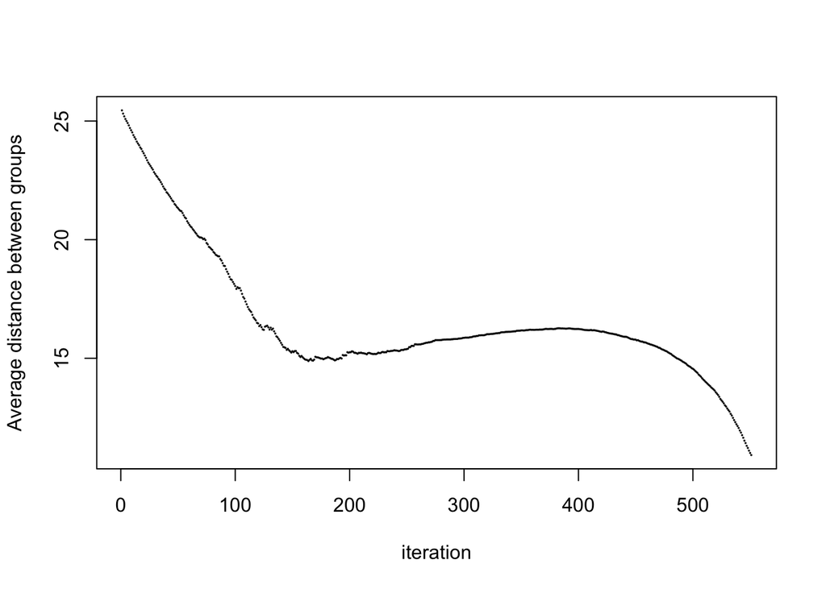

```r
plot(1:length(list_pca), abs(dist.vec), type="b", cex=0.1, xlab="iteration", ylab="Average distance between groups")
```

## 4.6 Assessing statistical significance

The next step is to assess for which iteration the distance becomes non significant from a statistical viewpoint. Here we adopted a simple approach based on the Wilcoxon test but other tests could be used:

```r
list_pca_tests <- vector("list", length=N+1)

for(i in 1:length(list_pca)){
  test <- wilcox.test(list_pca[[i]]$li[,1]~groups)
  list_pca_tests[[i]] <- test
  }
```

The function `unlist()` allows to store the p-values in a vector:

```r
p.values <- unlist(lapply(X=list_pca_tests, FUN=function(x) return(x$p.value)))
#p.values
```

Which p-values are significant at the 5% threshold? Significant and non-significant values are printed in red and grey respectively.

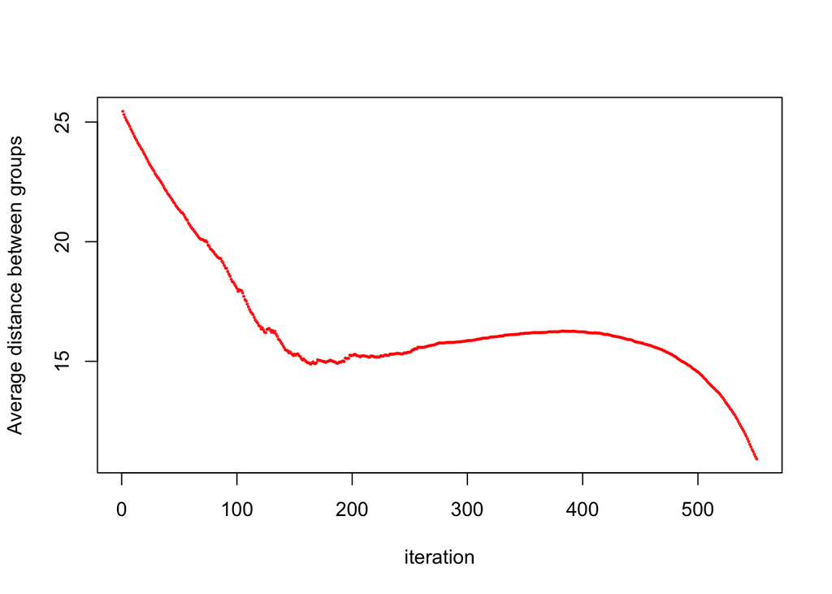

```r
ws <- which(p.values < 0.05) ; wns <- which(p.values >= 0.05)
dtemp <- data.frame(iteration=1:length(list_pca), dist=dist.vec)

plot(dtemp$iteration, dtemp$dist, type="n", xlab="iteration", ylab="Average distance between groups")
points(dtemp$iteration[ws], dtemp$dist[ws], type="p", cex=0.2, col="red")
points(dtemp$iteration[wns], dtemp$dist[wns], type="p", cex=0.1, col="grey")
```

Here we see that all values are significant, which means that scores of the two groups on pc1 are always statistically different.

# 5 Building an output `data.frame`

## 5.1 `data.frame` with the loci scores upon the first axis of the full PCA

The code below provides a `data.frame` with the loci scores upon the first axis of the full PCA sorted in descending order.

```r
genes.df <- data.frame(names(d))
genes.df[,1] <- as.character(genes.df[,1])
genes.df$score.cp1 <- pca$co[,1]
names(genes.df) <- c("loci", "pc1")
genes.df.ordered <- genes.df[order(-genes.df[,2]), ]
head(genes.df.ordered)
```

```
##        loci       pc1
## 367 loci430 0.8738155
## 103 loci193 0.8003328
## 136 loci222 0.7597904
## 567  loci85 0.7459044
## 238 loci314 0.7457877
## 580  loci97 0.7416996
```

```r
dim(genes.df.ordered)
```

```
## [1] 583   2
```

## 5.2 `data.frame` with full results of the iteration process

Based on the former `data.frame` a second output is created with the name of the removed locus and its score upon axis 1 in the initial PCA with full dataset, the probability level, the iteration number and the distance separating the groups.

```r
iteration.out <- genes.df.ordered[1:N,]
iteration.out$pvalue_wilcoxon <- p.values[-1] # remove the value corresponding to the full PCA
iteration.out$iteration <- 1:N

names(iteration.out) <- c("removed_loci", "score_pc1", "pvalue_wilcoxon", "iteration")

ws <- which(iteration.out$pvalue_wilcoxon < 0.05)
wns <- which(iteration.out$pvalue_wilcoxon >= 0.05)
iteration.out$significance <- rep(NA, times=dim(iteration.out)[1])
iteration.out$significance[ws] <- "s"
iteration.out$significance[wns] <- "ns"
iteration.out$distance <- dist.vec[-1] # remove the value corresponding to the full PCA
```

```r
head(iteration.out)
```

```
##     removed_loci score_pc1 pvalue_wilcoxon iteration significance distance
## 367      loci430 0.8738155    1.430225e-07         1            s 25.31441
## 103      loci193 0.8003328    1.430225e-07         2            s 25.19777
## 136      loci222 0.7597904    1.430225e-07         3            s 25.08763
## 567       loci85 0.7459044    1.430225e-07         4            s 25.00219
## 238      loci314 0.7457877    1.430225e-07         5            s 24.91740
## 580       loci97 0.7416996    1.430225e-07         6            s 24.81835
```

```r
tail(iteration.out)
```

```
##     removed_loci  score_pc1 pvalue_wilcoxon iteration significance
## 40       loci136 -0.5268541    1.430225e-07       545            s
## 378      loci440 -0.5291832    1.430225e-07       546            s
## 237      loci313 -0.5297948    1.430225e-07       547            s
## 500      loci550 -0.5318947    1.430225e-07       548            s
## 205      loci285 -0.5379546    1.430225e-07       549            s
## 429      loci487 -0.5413858    1.430225e-07       550            s
##     distance
## 40  11.42503
## 378 11.30836
## 237 11.21799
## 500 11.10616
## 205 11.00770
## 429 10.91887
```

If you want to save the table with the results to identify loci for which Wilcoxon tests are not significant, comment out the following command line (remove the #). A table named `iteration_out.csv` will be created in your current directory.

```r
#write.csv(x=iteration.out, file="iteration_out.csv", row.names = F)
```

# 6 Additional graphical outputs

## 6.1 Score of first N loci upon the first axis of the full PCA

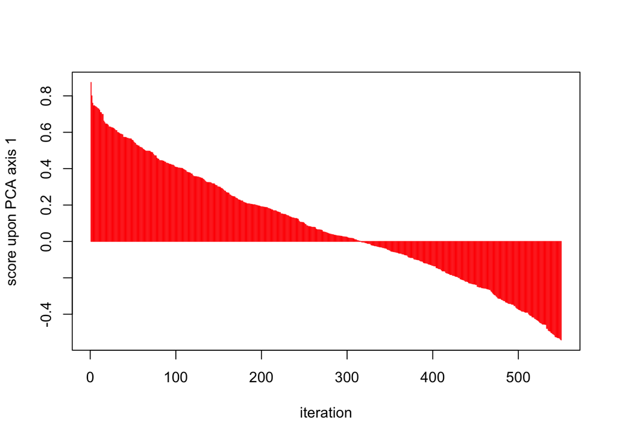

```r
plot(iteration.out$iteration, iteration.out$score_pc1, type="n", xlab="iteration", ylab="score upon PCA axis 1")
points(iteration.out$iteration[ws], iteration.out$score_pc1[ws], type="h", cex=0.2, col="red")
points(iteration.out$iteration[wns], iteration.out$score_pc1[wns], type="h", cex=0.2, col="grey")
```

## 6.2 Scatterplot of species scores for any PCA

Select one of the `N` PCA on “thinned” dataset and plot the species upon the first two principal axes.

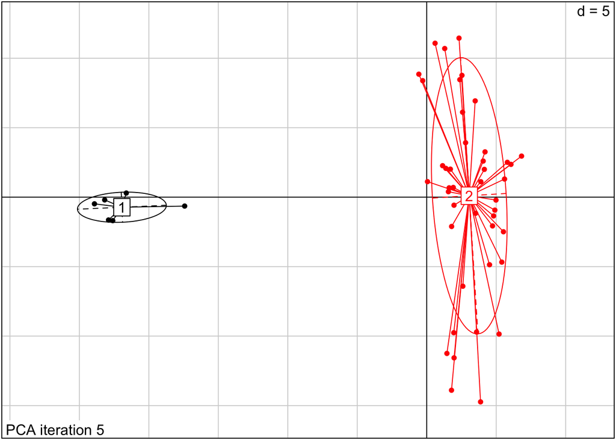

```r
i <- 5     #here we choose iteration 5
s.class(dfxy=list_pca[[i]]$li, fac=groups, col=c("black", "red"), sub=paste("PCA iteration ", i, sep=""))
```

# 7 Additional example corresponding to the figure FigS5

In this example, fig trees belonging to sect. *Pharmacosycea* are in group 2 (red) and all other fig trees are in group 1 (black). The analysed properties is the LB score for each locus of the mergeR1R2 data set. 500 iterative PCAs are performed. We can see on the resulting plots that scores of the two groups on pc1 are not always statistically different.

```r
rm(list=ls())
# reading the file example_figureS5.csv corresponding to Figure FigS5.
g <- GET(url="https://raw.githubusercontent.com/acruaud/radseq_ficus_2020/master/PCA/example_figureS5.csv")
d<-read.csv(g$url, sep=",", stringsAsFactors = F)

dim(d)
```

```
## [1]  71 532
```

```r
names(d)[1:5]
```

```
## [1] "class"       "taxa_labels" "locus_1003"  "locus_1008"  "locus_100"
```

```r
head(d)[1:5, 1:5]
```

```
##   class                    taxa_labels locus_1003 locus_1008  locus_100
## 1     1   F_salicifolia_FICU00029_0001  -20.67545  -2.210498  9.1916979
## 2     1 F_nymphaeifolia_FICU00033_0001         NA -22.498411  0.9341235
## 3     1   F_obtusifolia_FICU00035_0001         NA -17.813459 -6.8333599
## 4     1 F_cyathistipula_FICU00119_0001  -15.76866 -21.116232 12.2409124
## 5     1   F_ottonifolia_JRAS00341_0001         NA         NA 17.0582625
```

```r
unique(d$class)
```

```
## [1] 1 2
```

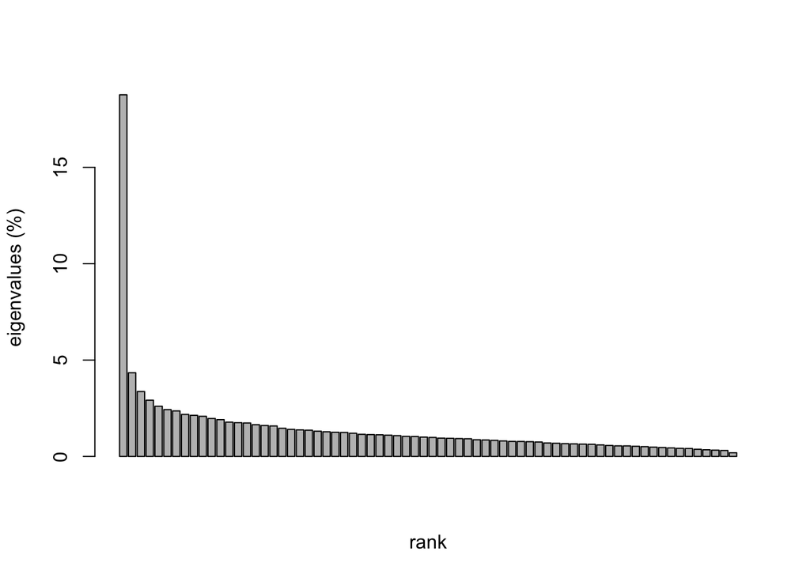

```r
NAtomean <- function(x) {x[which(is.na(x)==TRUE)] <- mean(x, na.rm=TRUE) ; return(x)}

labels <- d[,c(1,2)] ; d <- d[,-c(1,2)]
groups <- factor(labels[,1])
d <- data.frame(apply(X=d, MARGIN=2, FUN=NAtomean))

library(ade4)
pca <- dudi.pca(d, scannf = F, nf = 5)

barplot(height=100*pca$eig/sum(pca$eig), xlab="rank", ylab="eigenvalues (%)")
```

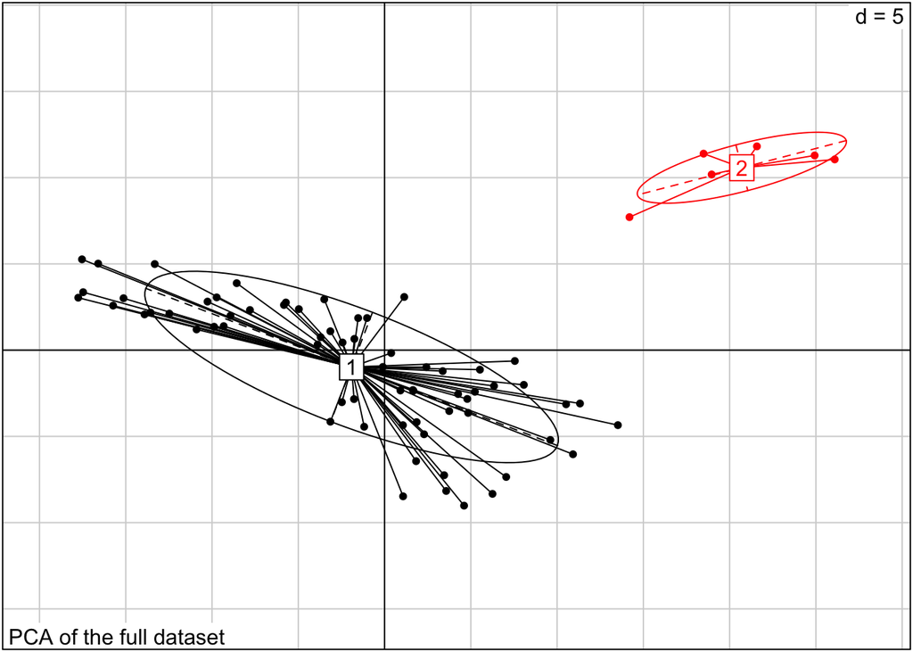

```r
s.class(dfxy=pca$li, fac=groups, col=c("black", "red"), sub="PCA of the full dataset")
```

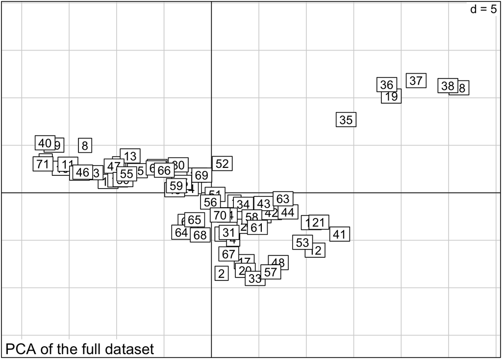

```r
s.label(dfxy=pca$li, xax = 1, yax = 2, label=row.names(d), sub="PCA of the full dataset")
```

```r
genes.df <- data.frame(names(d))
genes.df[,1] <- as.character(genes.df[,1])
genes.df$score.pc1 <- pca$co[,1]
names(genes.df) <- c("loci", "pc1")
head(genes.df)
```

```
##         loci       pc1
## 1 locus_1003 0.4682954
## 2 locus_1008 0.5787957
## 3  locus_100 0.4796818
## 4 locus_1012 0.4145553
## 5 locus_1015 0.5736779
## 6 locus_1017 0.4936843
```

```r
genes.df.ordered <- genes.df[order(-genes.df[,2]), ]
head(genes.df.ordered)
```

```
##           loci       pc1
## 284 locus_2418 0.7694634
## 121 locus_1537 0.7581057
## 415 locus_4870 0.7565349
## 246 locus_2194 0.7396730
## 115 locus_1515 0.7097486
## 42   locus_118 0.6932638
```

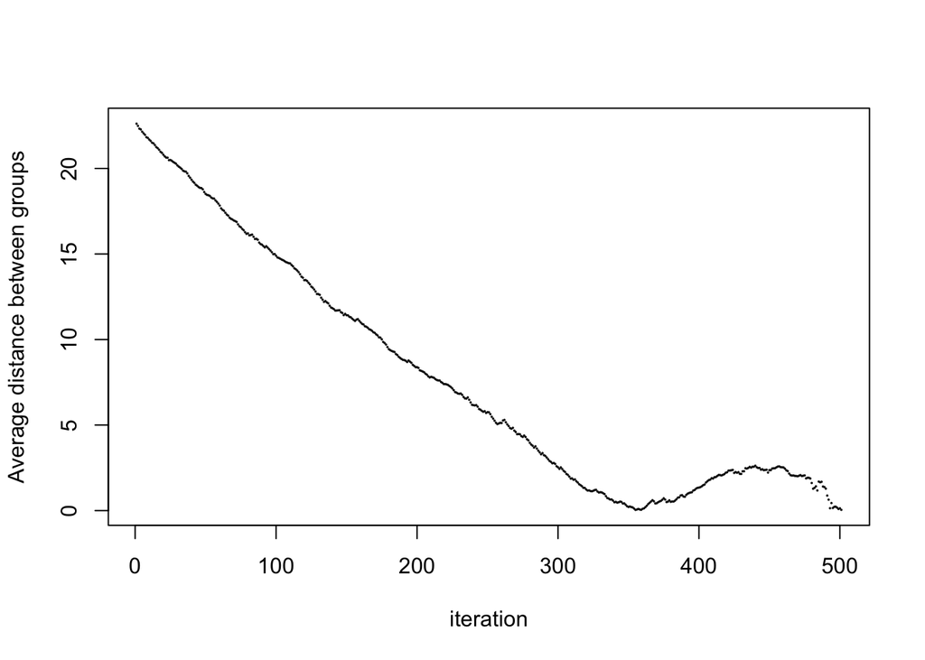

```r
N <- 500

lim <- 1 ; increm <- 1
list_pca <- vector("list", length=N+1)
list_pca[[1]] <- dudi.pca(d, scannf = F, nf = 5) # initial pca (i.e. with full dataset)

for(i in 1:(N)){
  retir <- genes.df.ordered[1:lim,1]
  m <- match(retir, names(d))
  temp <- d[,-m]
  list_pca[[i+1]] <- dudi.pca(temp, scannf = F, nf = 5)
  lim <- lim+increm
  }

dist.vec <- rep(NA, times=length(list_pca))

for(i in 1:length(list_pca)){
  w1 <- which(groups==levels(groups)[1])
  w2 <- which(groups==levels(groups)[2])
  pc1_g1 <- list_pca[[i]]$li[w1,1]
  pc1_g2 <- list_pca[[i]]$li[w2,1]
  diff <- mean(pc1_g1) - mean(pc1_g2)
  dist.vec[i] <- abs(diff)
  }

plot(1:length(list_pca), abs(dist.vec), type="b", cex=0.1, xlab="iteration", ylab="Average distance between groups")
```

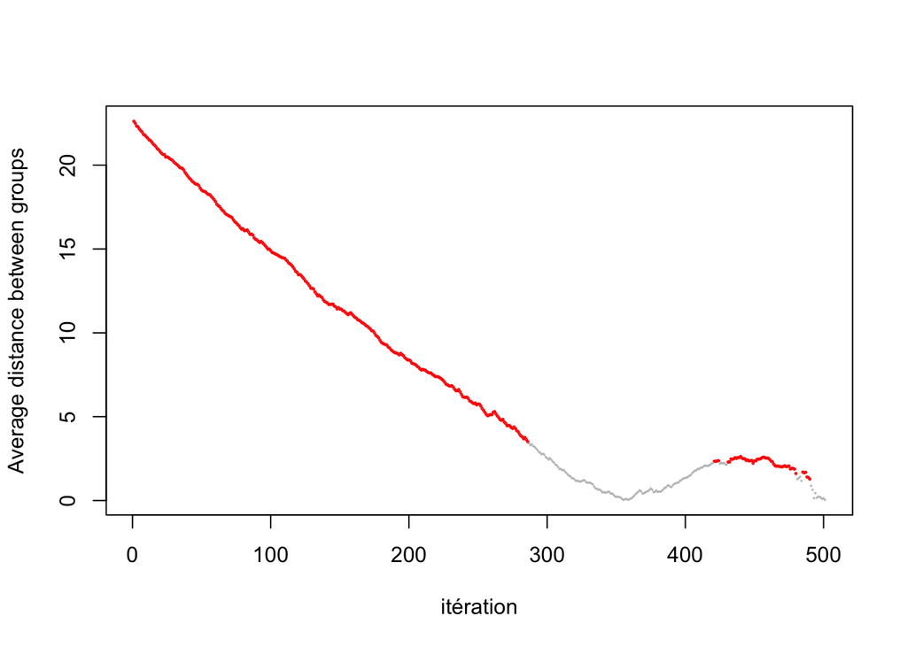

```r
list_pca_tests <- vector("list", length=N+1)

for(i in 1:length(list_pca)){
  test <- wilcox.test(list_pca[[i]]$li[,1]~groups)
  list_pca_tests[[i]] <- test
  }

p.values <- unlist(lapply(X=list_pca_tests, FUN=function(x) return(x$p.value)))

ws <- which(p.values < 0.05) ; wns <- which(p.values >= 0.05)
dtemp <- data.frame(iteration=1:length(list_pca), dist=dist.vec)

plot(dtemp$iteration, dtemp$dist, type="n", xlab="itération", ylab="Average distance between groups")
points(dtemp$iteration[ws], dtemp$dist[ws], type="p", cex=0.2, col="red")
points(dtemp$iteration[wns], dtemp$dist[wns], type="p", cex=0.1, col="grey")
```

```r
genes.df <- data.frame(names(d))
genes.df[,1] <- as.character(genes.df[,1])
genes.df$score.cp1 <- pca$co[,1]
names(genes.df) <- c("loci", "pc1")
genes.df.ordered <- genes.df[order(-genes.df[,2]), ]
head(genes.df.ordered)
```

```
##           loci       pc1
## 284 locus_2418 0.7694634
## 121 locus_1537 0.7581057
## 415 locus_4870 0.7565349
## 246 locus_2194 0.7396730
## 115 locus_1515 0.7097486
## 42   locus_118 0.6932638
```

```r
dim(genes.df.ordered)
```

```
## [1] 530   2
```

```r
iteration.out <- genes.df.ordered[1:N,]
iteration.out$pvalue_wilcoxon <- p.values[-1] # remove the value corresponding to the full PCA
iteration.out$iteration <- 1:N

names(iteration.out) <- c("removed_loci", "score_pc1", "pvalue_wilcoxon", "iteration")

ws <- which(iteration.out$pvalue_wilcoxon < 0.05)
wns <- which(iteration.out$pvalue_wilcoxon >= 0.05)
iteration.out$significance <- rep(NA, times=dim(iteration.out)[1])
iteration.out$significance[ws] <- "s"
iteration.out$significance[wns] <- "ns"
iteration.out$distance <- dist.vec[-1] # remove the value corresponding to the full PCA

head(iteration.out)
```

```
##     removed_loci score_pc1 pvalue_wilcoxon iteration significance distance
## 284   locus_2418 0.7694634    5.800264e-05         1            s 22.48913
## 121   locus_1537 0.7581057    5.800264e-05         2            s 22.32705
## 415   locus_4870 0.7565349    5.800264e-05         3            s 22.28195
## 246   locus_2194 0.7396730    5.800264e-05         4            s 22.15017
## 115   locus_1515 0.7097486    5.800264e-05         5            s 22.05145
## 42     locus_118 0.6932638    5.800264e-05         6            s 21.96657
```

```r
tail(iteration.out)
```

```
##     removed_loci score_pc1 pvalue_wilcoxon iteration significance
## 213   locus_2033 0.1203351       0.5697006       495           ns
## 38    locus_1175 0.1192069       0.7486476       496           ns
## 514    locus_932 0.1183380       0.7643674       497           ns
## 170   locus_1798 0.1131384       0.7643674       498           ns
## 492    locus_830 0.1117889       0.7021347       499           ns
## 439    locus_556 0.1107968       0.7801848       500           ns
##       distance
## 213 0.22032829
## 38  0.22912197
## 514 0.17323982
## 170 0.09201339
## 492 0.13500377
## 439 0.04247657
```

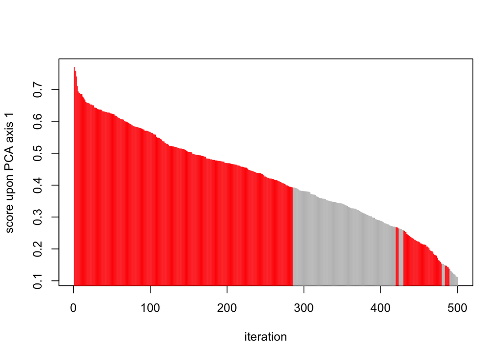

```r
plot(iteration.out$iteration, iteration.out$score_pc1, type="n", xlab="iteration", ylab="score upon PCA axis 1")
points(iteration.out$iteration[ws], iteration.out$score_pc1[ws], type="h", cex=0.2, col="red")
points(iteration.out$iteration[wns], iteration.out$score_pc1[wns], type="h", cex=0.2, col="grey")
```

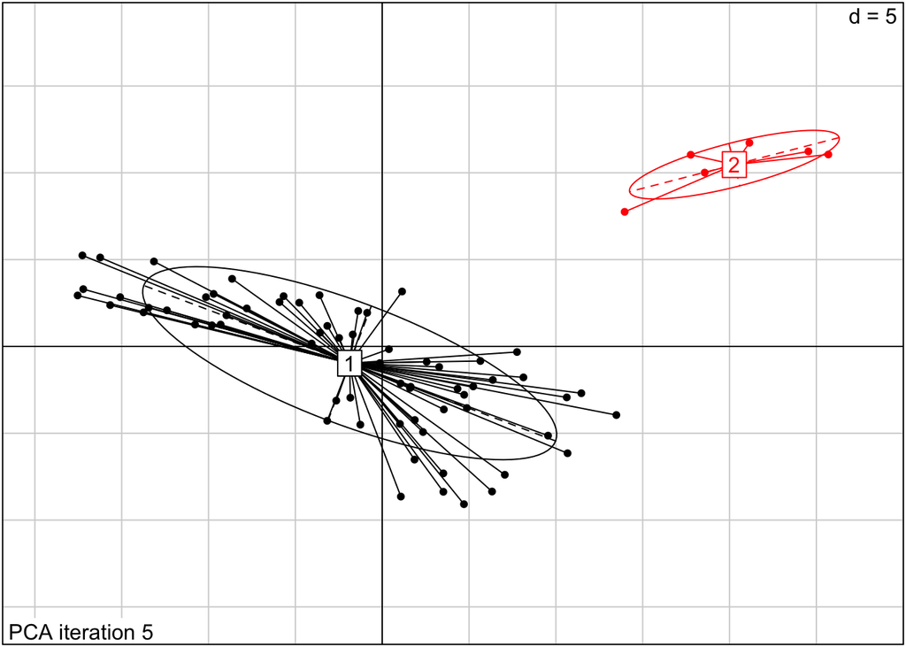

```r
i <- 5
s.class(dfxy=list_pca[[i]]$li, fac=groups, col=c("black", "red"), sub=paste("PCA iteration ", i, sep=""))
```

# 8 references

Dray, S. and Josse J. 2015. Principal component analysis with missing values: a comparative survey of methods. Plant Ecol 216:657–667.